# DPSS - Education Policy Capstone Research Project

Anne Velazquez

2022-09-14

## Introduction

The purpose of this analysis is to estimate the impact of the Safe Passage Program, a public policy designed and introduced by the the City of Chicago (see [here](https://www.cps.edu/services-and-supports/student-safety-and-security/safe-passage-program/) for more details on the program). The main purpose of the program is “to provide a positive, trusted adult presence for students as they travel to and from school.”

*First, clear the work space and load the necessary packages.*

```r
rm(list = ls())
library(readxl)
library(httr)
library(tidyverse)
library(dplyr)
library(ggplot2)
library(lubridate)
library(haven)
library(readxl)
library(plm)
library(sf)
library(leaflet)
library(lmtest)
#install.packages("leaflet.providers")
library(leaflet.providers)
library(stargazer)
#tinytex::install_tinytex()
```

*Read in all the data files for the analysis.*

1. “Attnd”: Attendance data for Chicago public schools
2. “control”: List of Chicago schools without the Safe Passage Program ang geographic information
3. “treatment: List of Chicago schools with the Safe Passage Program, when it was implemented and geographic information
4. “crimes”: Information on Chicago crimes within 500 yards of schools including crime type, location, and date of crime.
5. “schools_v_crime”: Chicago crimes that happened within 500 yards of school and their distance from the relevant school(s)

```r
## Data 1: school attendance data
attnd <- read_xlsx("metrics_attendance_2021.xlsx", sheet = "Overtime")

##can also read this file in directly from the web
# url <- "https://www.cps.edu/globalassets/cps-pages/about-cps/district-data/metrics/metrics_attendance_2021.xlsx"
# GET(url, write_disk(tf <- tempfile(fileext = ".xlsx")))
# attnd2 <- read_excel(tf, sheet = "Overtime")
# str(df)

## Data sets 2 and 3: Control schools vs treatments schools (i.e. ones with Safe passage program)
control <- read.csv("control.csv")
treated <- read.csv("treated.csv")

## Data 4: Crimes within 500 yards of schools
crimes <- read.csv("crime-data.csv")

## Data 5: Crimes that happened within 500 yards of school and distance from school
schools_v_crime <- read.csv("school-vs-crime-distances.csv")
```

## Data Cleaning and Exploration

### Question 1

*Format the school attendance data to use in the analysis.*

```r
#View the current school attendance data to understand its contents and format
head(attnd)
```

```
## # A tibble: 6 × 23
##   `School ID` `School Name` Network Group      Grade `2003` `2004` `2005` `2006`
##         <dbl> <chr>         <chr>   <chr>      <chr>  <dbl>  <dbl>  <dbl>  <dbl>
## 1          NA CITYWIDE      <NA>    All (Excl… <NA>    92.1   92.2   91.9   92.1
## 2          NA CITYWIDE      <NA>    Grade      Pre-K   84.4   84.3   80.8   81.2
## 3          NA CITYWIDE      <NA>    Grade      K       92.1   92.5   92.4   92.8
## 4          NA CITYWIDE      <NA>    Grade      1       93.8   94.3   93.8   94.2
## 5          NA CITYWIDE      <NA>    Grade      2       94.4   94.7   94.6   94.8
## 6          NA CITYWIDE      <NA>    Grade      3       94.5   94.8   94.7   95.1
## # … with 14 more variables: `2007` <dbl>, `2008` <dbl>, `2009` <dbl>,
## #   `2010` <dbl>, `2011` <dbl>, `2012` <dbl>, `2013` <dbl>, `2014` <dbl>,
## #   `2015` <dbl>, `2016` <dbl>, `2017` <dbl>, `2018` <dbl>, `2019` <dbl>,
## #   `2021` <dbl>
```

```r
## Part B: Reformat the data to be long rather than wide, filter to only years 2013-2018, and filter so we are only looking at overall school attendance rates rather than each individual grade
attnd_adj <- attnd %>%
  gather(key = "Year", value = "attnd_rate", 6:23)%>%
  mutate(Year = as.numeric(Year)) %>%
  filter(Year %in% 2013:2018)%>%
  filter(Group == "All (Excludes Pre-K)")

#Review the adjusted data
str(attnd_adj)
```

```
## tibble [5,136 × 7] (S3: tbl_df/tbl/data.frame)
##  $ School ID  : num [1:5136] NA 4e+05 4e+05 4e+05 4e+05 ...
##  $ School Name: chr [1:5136] "CITYWIDE" "ACT CHTR HS" "GLOBAL CITIZENSHIP" "ACE TECH HS" ...
##  $ Network    : chr [1:5136] NA NA "Charter" NA ...
##  $ Group      : chr [1:5136] "All (Excludes Pre-K)" "All (Excludes Pre-K)" "All (Excludes Pre-K)" "All (Excludes Pre-K)" ...
##  $ Grade      : chr [1:5136] NA NA NA NA ...
##  $ Year       : num [1:5136] 2013 2013 2013 2013 2013 ...
##  $ attnd_rate : num [1:5136] 92.5 NA 96.5 90.8 94.4 93.4 96.1 85.5 94.8 78.4 ...
```

### Question 2

#### Part A

*Combine the school attendance data with the ‘control’ and ‘treated’ data detailing which schools implemented the Safe Passage Program and where these schools are located.*

```r
## Bind the two control and treated datasets together to create a complete list of Chicago area schools and review the data
schools <- rbind(control, treated)
str(schools)
```

```
## 'data.frame':    519 obs. of  4 variables:
##  $ SCHOOLID             : int  400009 400010 400011 400013 400017 400021 400023 400024 400025 400026 ...
##  $ Lat                  : num  41.8 41.8 41.9 41.9 42 ...
##  $ Long                 : num  -87.7 -87.6 -87.7 -87.7 -87.7 ...
##  $ policy_implementation: int  NA NA NA NA NA NA NA NA NA NA ...
```

```r
## Prepare the school attendance data to be merged with the schools dataset

## make column name 'School ID' in the attendance data 'SCHOOLID' instead
colnames(attnd_adj)
```

```
## [1] "School ID"   "School Name" "Network"     "Group"       "Grade"
## [6] "Year"        "attnd_rate"
```

```r
colnames(attnd_adj)[1] <- "SCHOOLID"
colnames(attnd_adj)
```

```
## [1] "SCHOOLID"    "School Name" "Network"     "Group"       "Grade"
## [6] "Year"        "attnd_rate"
```

```r
## See how many unique school IDs are in each dataset
#length(unique(attnd_adj$SCHOOLID))
#length(unique(schools$SCHOOLID)) #the school attendance dataset has more schools

## Join the two datasets
## keep only school IDs from the 'schools' dataset which contains the treatment and control schools and their latitude and longitude information
school_data <- left_join(schools, attnd_adj, by = "SCHOOLID")
glimpse(school_data)
```

```
## Rows: 3,114
## Columns: 10
## $ SCHOOLID              <dbl> 400009, 400009, 400009, 400009, 400009, 400009, …
## $ Lat                   <dbl> 41.80758, 41.80758, 41.80758, 41.80758, 41.80758…
## $ Long                  <dbl> -87.74010, -87.74010, -87.74010, -87.74010, -87.…
## $ policy_implementation <int> NA, NA, NA, NA, NA, NA, NA, NA, NA, NA, NA, NA, …
## $ `School Name`         <chr> "GLOBAL CITIZENSHIP", "GLOBAL CITIZENSHIP", "GLO…
## $ Network               <chr> "Charter", "Charter", "Charter", "Charter", "Cha…
## $ Group                 <chr> "All (Excludes Pre-K)", "All (Excludes Pre-K)", …
## $ Grade                 <chr> NA, NA, NA, NA, NA, NA, NA, NA, NA, NA, NA, NA, …
## $ Year                  <dbl> 2013, 2014, 2015, 2016, 2017, 2018, 2013, 2014, …
## $ attnd_rate            <dbl> 96.5, 96.4, 95.9, 96.3, 96.0, 95.3, 90.8, 89.4, …
```

```r
#confirm that this new data has the same number of School IDs as the schools dataset
#length(unique(school_data$SCHOOLID)) == length(unique(schools$SCHOOLID))

## Add a column to this dataframe to identify whether a school was a "treated" (had the safe passage program) or a "control" school
school_data <- school_data  %>%
  mutate(treatment = as.factor(ifelse(is.na(policy_implementation), "control", "treated")))

## Check the number of treated vs. control schools for each year in the dataset
school_data %>%
  group_by(Year, treatment) %>%
  summarize(schools = n())
```

```
## # A tibble: 12 × 3
## # Groups:   Year [6]
##     Year treatment schools
##    <dbl> <fct>       <int>
##  1  2013 control       475
##  2  2013 treated        44
##  3  2014 control       475
##  4  2014 treated        44
##  5  2015 control       475
##  6  2015 treated        44
##  7  2016 control       475
##  8  2016 treated        44
##  9  2017 control       475
## 10  2017 treated        44
## 11  2018 control       475
## 12  2018 treated        44
```

#### Part B

*Create a map displaying the treated and control schools, with each group of schools in a different color.*

```r
## Set up the color scheme to identify treated vs. control schools
color_string <- c("gray", "yellow")
pal <- colorFactor(color_string, school_data$treatment)

## Map the treated vs. the control schools, and filter to just one year of data so there is only one point on the map per school
school_data %>%
  filter(Year == 2015) %>%
leaflet() %>%
  addProviderTiles("CartoDB.DarkMatter") %>%
  addCircles(
    lat = ~ Lat,
    lng = ~ Long,
    color = ~ pal(treatment),
    opacity = 0.9,
  ) %>%
  addLegend("topright", colors = color_string, values = ~treatment,
            labels = c("w/o Safe Passage Program (control)", "w/ Safe Passage Program (treated)"),
    title = "School Type")
```

[interactive chart not shown]

From the map of the treated schools compared to control schools, the treated schools do not appear to be evenly distributed throughout the Chicago area. Most schools with the safe passage program (treated) are in the southern part of Chicago. There is a higher concentration of treated schools near the South Side, New City, and Englewood areas specifically. Treated schools generally appear more concentrated near the center of the city and are less prevalent towards the edges of the city.

### Question 3

#### Part A

*Load and organize the Chicago crime data for the analysis.*

```r
## Load the ‘crime.csv’ and the ‘school-crime-distance.csv’ datasets into your R current session.

#crimes <- read.csv("crime-data.csv")
#schools_v_crime <- read.csv("school-vs-crime-distances.csv")

## Review the data frames
str(crimes)
```

```
## 'data.frame':    660026 obs. of  6 variables:
##  $ ID                  : int  10230577 10232012 10239538 10242736 10250689 10252525 10262776 10272586 10281036 10310725 ...
##  $ Date                : chr  "03/01/2013 08:00:00 AM" "02/12/2013 09:00:00 AM" "01/01/2013 12:00:00 PM" "07/30/2013 12:01:00 AM" ...
##  $ Primary.Type        : chr  "DECEPTIVE PRACTICE" "DECEPTIVE PRACTICE" "DECEPTIVE PRACTICE" "OBSCENITY" ...
##  $ Location.Description: chr  "OTHER" "OTHER" "OTHER" "OTHER" ...
##  $ Latitude            : num  41.8 41.9 41.9 41.8 41.9 ...
##  $ Longitude           : num  -87.6 -87.6 -87.6 -87.7 -87.8 ...
```

```r
str(schools_v_crime)
```

```
## 'data.frame':    917319 obs. of  3 variables:
##  $ CRIME_ID: int  9005375 9006777 9018239 9024727 9025864 9034301 9037339 9039379 9041022 9045041 ...
##  $ SCHOOLID: int  400009 400009 400009 400009 400009 400009 400009 400009 400009 400009 ...
##  $ distance: num  281 303 298 289 474 ...
```

```r
## Join the two crime datasets together so, at the end, you have a dataset containing the crime that occurred in Chicago between 2013 and 2018 and their distance from Chicago Public Schools.

## Prep the datasets to join them
#colnames(crimes)
#colnames(schools_v_crime)
colnames(crimes)[1] <- "CRIME_ID"

crime_join <- full_join(crimes, schools_v_crime, by = "CRIME_ID")
str(crime_join)
```

```
## 'data.frame':    917319 obs. of  8 variables:
##  $ CRIME_ID            : int  10230577 10232012 10232012 10239538 10239538 10242736 10250689 10250689 10252525 10262776 ...
##  $ Date                : chr  "03/01/2013 08:00:00 AM" "02/12/2013 09:00:00 AM" "02/12/2013 09:00:00 AM" "01/01/2013 12:00:00 PM" ...
##  $ Primary.Type        : chr  "DECEPTIVE PRACTICE" "DECEPTIVE PRACTICE" "DECEPTIVE PRACTICE" "DECEPTIVE PRACTICE" ...
##  $ Location.Description: chr  "OTHER" "OTHER" "OTHER" "OTHER" ...
##  $ Latitude            : num  41.8 41.9 41.9 41.9 41.9 ...
##  $ Longitude           : num  -87.6 -87.6 -87.6 -87.6 -87.6 ...
##  $ SCHOOLID            : int  610047 610231 400064 610534 400113 400112 610068 610533 610142 400098 ...
##  $ distance            : num  331.1 329.1 175.5 427.3 94.9 ...
```

```r
## Convert Date column from character to date format
#crime_join$Date[1]
#mdy_hms(crime_join$Date[1])
crime_join$Date <- mdy_hms(crime_join$Date)

## Add Year column to crime data
crime_join <- crime_join %>%
  mutate(Year = year(Date))

#Review new data
str(crime_join)
```

```
## 'data.frame':    917319 obs. of  9 variables:
##  $ CRIME_ID            : int  10230577 10232012 10232012 10239538 10239538 10242736 10250689 10250689 10252525 10262776 ...
##  $ Date                : POSIXct, format: "2013-03-01 08:00:00" "2013-02-12 09:00:00" ...
##  $ Primary.Type        : chr  "DECEPTIVE PRACTICE" "DECEPTIVE PRACTICE" "DECEPTIVE PRACTICE" "DECEPTIVE PRACTICE" ...
##  $ Location.Description: chr  "OTHER" "OTHER" "OTHER" "OTHER" ...
##  $ Latitude            : num  41.8 41.9 41.9 41.9 41.9 ...
##  $ Longitude           : num  -87.6 -87.6 -87.6 -87.6 -87.6 ...
##  $ SCHOOLID            : int  610047 610231 400064 610534 400113 400112 610068 610533 610142 400098 ...
##  $ distance            : num  331.1 329.1 175.5 427.3 94.9 ...
##  $ Year                : num  2013 2013 2013 2013 2013 ...
```

#### Part B

*Create a map that shows all the crimes that took place within a 50 yard distance from schools to see if crimes are concentrated in any particular area of the city.*

Based on the following maps, crimes in Chicago from 2013-2018 within 50 yards of schools appear more highly concentrated near the center of the city.

```r
#Map of all crimes from 2013-2018 within 50 yards of schools
crime_join %>%
  filter(distance <= 50) %>%
  leaflet() %>%
  addProviderTiles("CartoDB.DarkMatter") %>%
  addCircles(
    lat = ~ Latitude,
    lng = ~ Longitude,
    opacity = 0.2,
    color = "red"
  )
```

[interactive chart not shown]

```r
#Map of all crimes from 2013-2018 within 50 yards of schools
#Cluster version
crime_join %>%
  filter(distance <= 50) %>%
  leaflet() %>%
  addProviderTiles("CartoDB.DarkMatter") %>%
  addMarkers(
    clusterOptions = markerClusterOptions()
  )
```

[interactive chart not shown]

## Analysis and Results

### Question 4

*In order to use fixed effects regression analysis to evaluate the impact of the Safe Passage Program on crime near schools, first we must confirm if the ‘parallel trends’ assumption holds. In other words, we will confirm if crime rates near schools with the Safe Passage Program were trending similarly to those without the program. If this is true, we can use fixed effects regression to analyze the impact of the program.*

*First, create a new data frame which should contain for each ‘SCHOOLID’ the total count of crimes that took place within a 50 yard distance from the school for each year of the dataset from 2013 to 2018.*

```r
df_crime_scl <- crime_join %>%
  mutate(Year = year(Date)) %>%
  group_by(SCHOOLID, Year) %>%
  summarize(crime_count_50yd = sum(distance <= 50),
            crime_count_200yd = sum(distance <= 200))

head(df_crime_scl, 10)
```

```
## # A tibble: 10 × 4
## # Groups:   SCHOOLID [2]
##    SCHOOLID  Year crime_count_50yd crime_count_200yd
##       <int> <dbl>            <int>             <int>
##  1   400009  2013                4                30
##  2   400009  2014                7                60
##  3   400009  2015                3                23
##  4   400009  2016                2                25
##  5   400009  2017                2                20
##  6   400009  2018                1                54
##  7   400010  2013               17                43
##  8   400010  2014               18                43
##  9   400010  2015               18                58
## 10   400010  2016               19                50
```

```r
# #check how many rows of data there should be given schools and years
# length(unique(crime_join$Year))*length(unique(crime_join$SCHOOLID))
# nrow(df_crime_scl)
# ##The dataset accounts for all schools and years
```

*Now join the summarized crime data with the school data. Make sure that before joining them, the school_data only contains the following columns: (i) one for the schoolid; (ii) one for latitude; (iii) one for longitude; (iv) one indicating if the schools is part of the safe passage or not; (v) one indicating the year the policy was implemented; (vi) the attendance rate percentage for that SchoolID.*

```r
## Check how many unique schools are in the crime data
# length(unique(crime_join$SCHOOLID))
#
# #confirmed the crime dataset has the same # of school IDs as school_data
# length(unique(crime_join$SCHOOLID)) == length(unique(school_data$SCHOOLID))


#Join the two data frames using SchoolID and Year so we have data that shows each school for years 2013-2018, whether they were treated, when they were treated, and the attendance rate and crime counts for each year

# glimpse(school_data) #check names of columns needed

# Join crimes summary data with school data
# only need columns SCHOOLID, lat, long, treatment, policy_implementation, Year, attnd_rate
# use right join to only keep the School IDs in the df_crime_scl dataset

df_sum_scl_crime <- school_data %>%
  select(SCHOOLID, treatment, policy_implementation, Year, attnd_rate, Lat, Long) %>%
  right_join(., df_crime_scl, by = c('SCHOOLID', 'Year')) %>%
  arrange(SCHOOLID)

str(df_sum_scl_crime)
```

```
## 'data.frame':    3114 obs. of  9 variables:
##  $ SCHOOLID             : num  4e+05 4e+05 4e+05 4e+05 4e+05 ...
##  $ treatment            : Factor w/ 2 levels "control","treated": 1 1 1 1 1 1 1 1 1 1 ...
##  $ policy_implementation: int  NA NA NA NA NA NA NA NA NA NA ...
##  $ Year                 : num  2013 2014 2015 2016 2017 ...
##  $ attnd_rate           : num  96.5 96.4 95.9 96.3 96 95.3 90.8 89.4 88.1 87.6 ...
##  $ Lat                  : num  41.8 41.8 41.8 41.8 41.8 ...
##  $ Long                 : num  -87.7 -87.7 -87.7 -87.7 -87.7 ...
##  $ crime_count_50yd     : int  4 7 3 2 2 1 17 18 18 19 ...
##  $ crime_count_200yd    : int  30 60 23 25 20 54 43 43 58 50 ...
```

*Use this data frame to create a plot that visually verifies the parallel trends assumption necessary for fixed effects regression.*

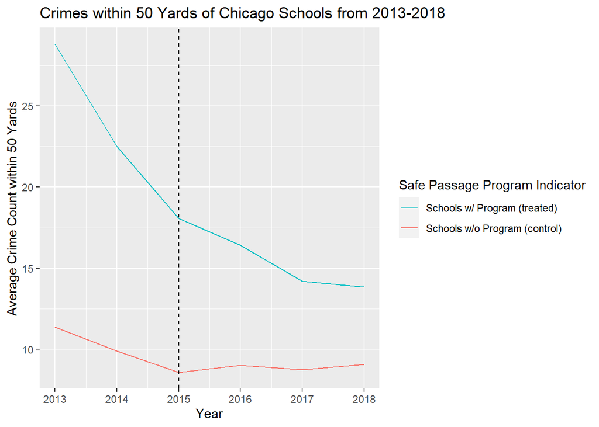

```r
#levels(df_sum_scl_crime$treatment) #check levels of treatment variable

#Graph of average crimes within 50 yards
df_sum_scl_crime %>%
  group_by(treatment, Year) %>%
  summarise(Avg_crimes = mean(crime_count_50yd)) %>%
  ggplot()+
  geom_line(aes(
    x = Year,
    y = Avg_crimes,
    color = treatment))+
  geom_vline(xintercept = 2015, linetype = "dashed") +
  guides(col = guide_legend(reverse = TRUE)) +
  scale_color_discrete(
    name = "Safe Passage Program Indicator",
    labels = c("Schools w/o Program (control)", "Schools w/ Program (treated)")) +
  labs(
    title = "Crimes within 50 Yards of Chicago Schools from 2013-2018",
    x = "Year",
    y = "Average Crime Count within 50 Yards"
  )
```

The graph shows that, on average, all schools had decreasing rates of crime within 50 yards prior to 2015. After 2015, schools with the Safe Passage Program continued to see nearby crime decrease on average through 2018, while schools without the program saw nearby crimes increase slightly and hold relatively flat through 2018. In short, nearby crime rates were trending similarly at all schools before the the Safe Passage Program was implemented in 2015.

If instead we look at crimes within 200 yards of schools, the trend of crime rates prior to 2015 appears more parallel between schools with and without the Safe Passage Program.

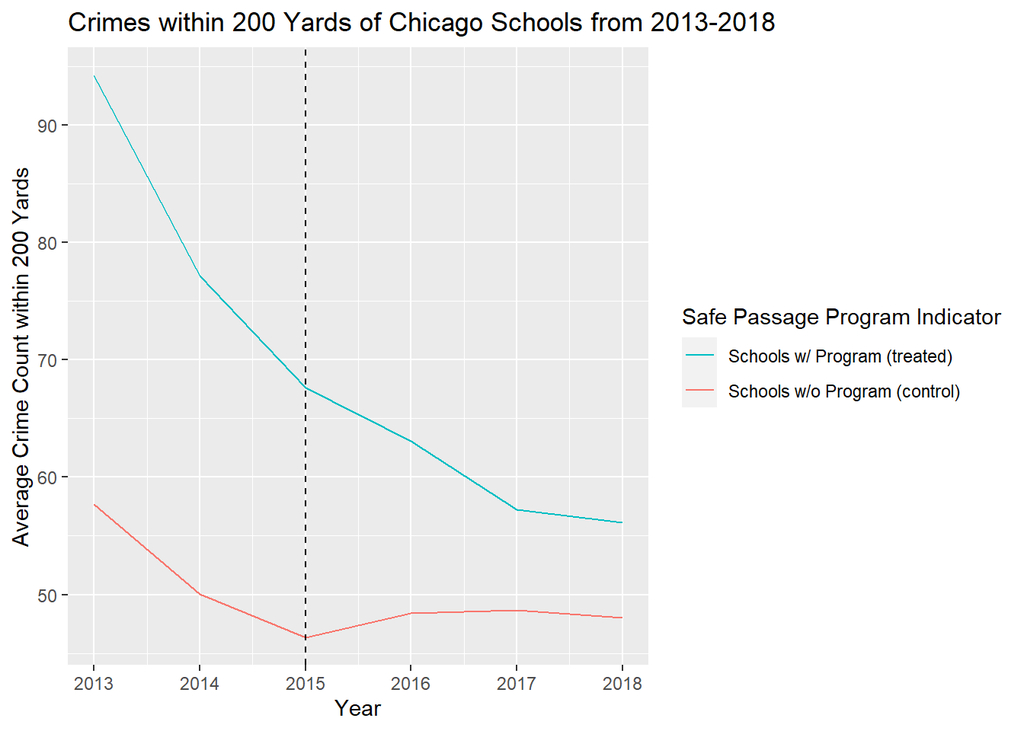

```r
#Graph of average crimes within 200 yards
df_sum_scl_crime %>%
  group_by(treatment, Year) %>%
  summarise(Avg_crimes = mean(crime_count_200yd)) %>%
  ggplot()+
  geom_line(aes(
    x = Year,
    y = Avg_crimes,
    color = treatment))+
  geom_vline(xintercept = 2015, linetype = "dashed") +
  guides(col = guide_legend(reverse = TRUE)) +
  scale_color_discrete(
    name = "Safe Passage Program Indicator",
    labels = c("Schools w/o Program (control)", "Schools w/ Program (treated)")) +
  labs(
    title = "Crimes within 200 Yards of Chicago Schools from 2013-2018",
    x = "Year",
    y = "Average Crime Count within 200 Yards"
  )
```

Now look at trends for school attendance rates. From the chart below, it does not look like the parallel trend assumption holds for school attendance rates.

```r
#Graph of attendance rates
head(df_sum_scl_crime)
```

```
##   SCHOOLID treatment policy_implementation Year attnd_rate      Lat     Long
## 1   400009   control                    NA 2013       96.5 41.80758 -87.7401
## 2   400009   control                    NA 2014       96.4 41.80758 -87.7401
## 3   400009   control                    NA 2015       95.9 41.80758 -87.7401
## 4   400009   control                    NA 2016       96.3 41.80758 -87.7401
## 5   400009   control                    NA 2017       96.0 41.80758 -87.7401
## 6   400009   control                    NA 2018       95.3 41.80758 -87.7401
##   crime_count_50yd crime_count_200yd
## 1                4                30
## 2                7                60
## 3                3                23
## 4                2                25
## 5                2                20
## 6                1                54
```

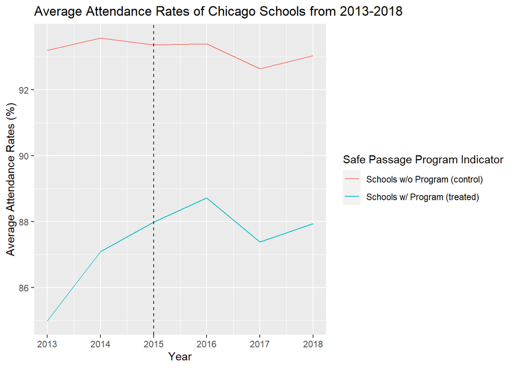

```r
df_sum_scl_crime %>%
  group_by(treatment, Year) %>%
  summarise(Avg_attend = mean(attnd_rate)) %>%
  ggplot()+
  geom_line(aes(
    x = Year,
    y = Avg_attend,
    color = treatment))+
  geom_vline(xintercept = 2015, linetype = "dashed") +
  guides(col = guide_legend(reverse = FALSE)) +
  scale_color_discrete(
    name = "Safe Passage Program Indicator",
    labels = c("Schools w/o Program (control)", "Schools w/ Program (treated)")) +
  labs(
    title = "Average Attendance Rates of Chicago Schools from 2013-2018",
    x = "Year",
    y = "Average Attendance Rates (%)"
  )
```

```r
#try changing scale a bit, but still dont think this holds
```

### Question 5

#### Part A

*Run a fixed effects regression of total crime in the presence of the Safe Passage Policy. It should also include both ‘school’ fixed effects and ‘year’ fixed effects.*

```r
#First, add a column to the data that indicates whether the safe passage program was in effect for the school in that year

df_sum_scl_crime <- df_sum_scl_crime %>%
  mutate(spp_active = factor(ifelse(Year >= 2015 & treatment == "treated", "Yes", "No")))

# glimpse(df_sum_scl_crime) #view the aadded column
#levels(df_sum_scl_crime$spp_active) #confirm levels of new variable

#Now run a fixed effects regression model with year and schoool as fixed effects to see if the SPP had a significant impact on crimes near schools
library(plm)

# colnames(df_sum_scl_crime) #check names of variables
# head(df_sum_scl_crime)

#Model based on crimes within 50 yards of schools
model_50_crime <- plm(crime_count_50yd ~ spp_active, data = df_sum_scl_crime, model = "within", effect = "twoways", index = c("SCHOOLID","Year"))

#summary(model_50_crime)
coef_model_50_crime <- coeftest(model_50_crime, vcov. = vcovHC, type = 'HC1')
coef_model_50_crime
```

```
##
## t test of coefficients:
##
##               Estimate Std. Error t value  Pr(>|t|)
## spp_activeYes  -8.2401     2.4066  -3.424 0.0006267 ***
## ---
## Signif. codes:  0 '***' 0.001 '**' 0.01 '*' 0.05 '.' 0.1 ' ' 1
```

```r
#Model based on crimes within 200 yards
model_200_crime <- plm(crime_count_200yd ~ spp_active, data = df_sum_scl_crime, model = "within", effect = "twoways", index = c("SCHOOLID","Year"))
coef_model_200_crime <- coeftest(model_200_crime, vcov. = vcovHC, type = 'HC1')
coef_model_200_crime
```

```
##
## t test of coefficients:
##
##               Estimate Std. Error t value  Pr(>|t|)
## spp_activeYes -18.6919     4.3766 -4.2709 2.017e-05 ***
## ---
## Signif. codes:  0 '***' 0.001 '**' 0.01 '*' 0.05 '.' 0.1 ' ' 1
```

```r
#Summary results of both crime models
stargazer(model_50_crime, model_200_crime, report=("vc*p"), title = "Results", header = FALSE, type = "text", p = c(coef_model_50_crime[4], coef_model_200_crime[4]), omit.stat=c("adj.rsq", "f", "rsq"))
```

```
##
## Results
## ================================================
##                      Dependent variable:
##               ----------------------------------
##               crime_count_50yd crime_count_200yd
##                     (1)               (2)
## ------------------------------------------------
## spp_activeYes    -8.240***        -18.692***
##                  p = 0.001        p = 0.00003
##
## ------------------------------------------------
## Observations       3,114             3,114
## ================================================
## Note:                *p<0.1; **p<0.05; ***p<0.01
```

The coefficient for the indicator variable is -8.24, which means that schools with the Safe Passage Program in effect have 8.24 fewer nearby crimes on average each year compared to schools that did not implement the Safe Passage Program. The p-value for this coefficient is significant at the .001 level. This means that the Safe Passage Program has a statistically significant relationship with the rate of crimes within 50 yards of schools. By including fixed effects for schools and each year in the model, we eliminate the risk of bias due to omitted factors that vary across schools and that vary over time.

#### Part B

*Run the same regression as in (a), but now run of school attendance on the presence of the Safe Passage Policy.*

```r
model_attend <- plm(attnd_rate ~ spp_active, data = df_sum_scl_crime, model = "within", effect = "twoways", index = c("SCHOOLID","Year"))

#summary(model_attend)

coef_model_attend <- coeftest(model_attend, vcov. = vcovHC, type = 'HC1')
coef_model_attend
```

```
##
## t test of coefficients:
##
##               Estimate Std. Error t value  Pr(>|t|)
## spp_activeYes  2.24453    0.49242  4.5582 5.399e-06 ***
## ---
## Signif. codes:  0 '***' 0.001 '**' 0.01 '*' 0.05 '.' 0.1 ' ' 1
```

```r
as.numeric(round(coef_model_attend[4], 5))
```

```
## [1] 1e-05
```

```r
#Summary results of all 3 models
stargazer(model_50_crime, model_200_crime, model_attend, report=("vc*p"), title = "Results", header = FALSE, type = "text", p = c(coef_model_50_crime[4], coef_model_200_crime[4], coef_model_attend[4]), omit.stat=c("adj.rsq", "f", "rsq"))
```

```
##
## Results
## ============================================================
##                            Dependent variable:
##               ----------------------------------------------
##               crime_count_50yd crime_count_200yd attnd_rate
##                     (1)               (2)            (3)
## ------------------------------------------------------------
## spp_activeYes    -8.240***        -18.692***      2.245***
##                  p = 0.001        p = 0.00003    p = 0.00001
##
## ------------------------------------------------------------
## Observations       3,114             3,114          3,114
## ============================================================
## Note:                            *p<0.1; **p<0.05; ***p<0.01
```

The coefficient for the indicator variable is 2.245, which means that schools with the Safe Passage Program in effect had attendance rates that were 2.24 percentage points higher on average compared to schools that did not implement the Safe Passage Program. The p-value for this coefficient is significant at the .001 level. This means that the Safe Passage Program has a statistically significant relationship with school attendance rates.